# PreLab 8: Classification: Cancer Diagnosis

Introduction to Data Mathematics 2021

Jared Gridley

# Overview

In this prelab, you will be making a classifier that determines if a cancer sample is benign or malignant using LDA.

Start the lab by saving the master `.Rmd` file to your local directory and editing the header to include your name.

This prelab uses the Wisconsin Breast Cancer Data (WBCD)

Each sample consists of 30 features that are computed from a digitized image of a fine needle aspirate (FNA) of a breast mass. They describe characteristics of the cell nuclei present in the image. There is also a label of B or M indicating if the sample is benign or malignant. In lecture, we refer to the classes generically as Class -1 or Class 1. In this case we consider Class B = Class -1 and Class M = Class 1.

```r
# Prepare WBCD data
Q.df <- read.csv("~/MATP-4400/data/wdbc.csv")
# get the features and scale them on the entire dataset
Q<- as.data.frame(scale(Q.df[ ,3:32],center = TRUE,scale = FALSE))
d <- ncol(Q)
# We give the features names
colnames(Q)<-sprintf('V%d',1:d)
# The labels are M for malignant and B for benign
labels<-Q.df[,2]
```

# Constructing a Classifier with LDA

Our task is to make a classifier that classifies tumor samples as benign (class B or -1) or malignant (class M or 1) using LDA. Randomly divide the data into a set consisting of 90% training and 10% testing. Then construct the Fisher LDA model on the training set.

```r
#Split the data into training and testing sets
#ss will be the number of data in the training set
n <- nrow(Q)
ss<- ceiling(n*0.9)

#Set random seed to ensure reproducibility
set.seed(300)
train.perm <- sample(1:n,ss)

#The first column is just the sample label, we can discard it for statics (This is the -1 in the second position)
trainmatrix <- as.matrix(Q[train.perm , ])  #The training data is just the training rows
testmatrix <- as.matrix(Q[-train.perm, ]) # Using -train gives us all rows except the training rows.
#The last column is the class label, which is 1 or -1, we can split it off as the class
trainclass <- labels[train.perm]
testclass <- labels[-train.perm]

# Make a train.df and test.df dataframes combining labels and features
train.df<-data.frame(trainmatrix, class=as.factor(trainclass))
test.df<-data.frame(testmatrix, class=as.factor(testclass))
```

- The data is called “train.df”.
- The formula ‘class~x’ specifies the variable to be predicted on the left hand side and the features to use for prediciton on the right. In this case, we want to predict ‘class’. The ‘~." means predict with all the features except ’class’, which means using V1 through V30. You can do other formulas, for example ‘class ~ V1+V2’ would predict the class using only features V1 and V2.
- The “prior” option specifies weighting between classes. This uses (1/2,1/2). The default weights by class size.

Let’s do a visualization to see how the linear discriminant works. The scalar projection of each point on the normal of the separating hyperplane is calculated.

The scalar projections on the normal for LDA for the training data are illustrated using the following histograms. They show the scalar projections for each class and the value of the threshold used to separate them.

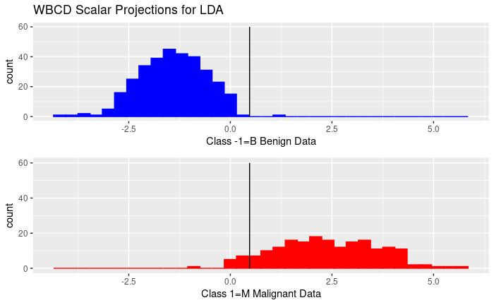

## Performance of Model

- Now we calculate how well the LDA model does on WBCD training and testing data in terms of class M (or 1) accuracy, class B (or -1) accuracy, and balanced accuracy.
- Class 1 accuracy is the number of correctly classified points in Class 1 divided by the number of points in Class 1. For this problem, class M is the same as Class 1.
- Class -1 accuracy is the number of correctly classified points in Class -1 divided by the number of points in Class -1. For this problem, class B is the same as Class -1.
- Balanced accuracy is the mean of the Class 1 accuracy and the Class -1 accuracy or equivalently the mean of the Class B and Class M accuracies for this problem.

The predictions on the training data results in the following confusion matrix. The rows are the actual classes and the columns are the predicted classes.

```r
# kable formats a table to look nice in notebook
kable(confusion.matrix, digits = 2)
```

|  | B | M |
| --- | --- | --- |
| B | 321 | 1 |
| M | 16 | 175 |

- ‘confusionmatrix[1,1]=321’ is the number of B points that are correctly classified.
- ‘confusionmatrix[2,2,]=175’ is the number of M points that are correctly classified.
- ‘confusionmatrix[1,2]=1’ is the number of B points misclassified as M.
- ‘confusionmatrix[2,1,]=16’ is the number of M points misclassified as B.

Calculate the balanced accurcy on the training data.

The LDA method correctly classified 91.6230366% of the positive training data and 99.689441% of the negative training data. The balanced training accuracty was 95.6562388%.